# Supplementary Figure 3: Children vs adult neutrophils of SARS-CoV-2 patients (scRNA-Seq)

Carlos Ramirez

2026-10-27 17:09:43

This markdown reproduces the panels of **Supplementary Figure 3**. It complements Figure 3 (`figure_03.Rmd`), in which the RIG-I-only and STAT-only signatures were projected onto the nasal-swab single-cell RNA-Seq data of SARS-CoV-2 positive and negative children and adults of [Loske et al. 2021, Nat. Biotechnol.](https://www.nature.com/articles/s41587-021-01037-9). In Figure 3, neutrophils carrying SARS-CoV-2 transcripts from children showed high RIG-I-only scores. Here, we compare these neutrophils between SARS-CoV-2 positive children and adults with a differential expression analysis (Seurat `FindMarkers`, Wilcoxon test) and a gene set enrichment analysis (GSEA, GO Biological Process, `clusterProfiler::gseGO`) of the genes up-regulated in children.

Panels produced (all saved in `figures/supplementary_figure_03/`):

| Panel file | Content |
| --- | --- |
| `volcano_plot_childern_vs_adult.pdf` | Volcano plot of the differential expression between neutrophils of SARS-CoV-2 positive children and adults; RIG-I-only signature genes in blue |
| `dotplot_gsea.pdf` | GSEA (GO BP) of the top 200 genes up-regulated in children neutrophils |

The code was taken from the original analysis script `/media/ag-cherrmann/cramirez/interferon_model/scripts/R/july_2026/03_scRNASeq_projections_loske.Rmd` (which wrote `volcano_plot_childern_vs_adult.pdf` to `figures/2026_May/` and `dotplot_gsea.pdf` to `figures/2026_September/` on 2026-10-01). Only the code needed for these panels was kept; plotting code, PDF sizes and aesthetics are unchanged.

**Dependency on `figure_03.Rmd`.** The neutrophil subset (Seurat object of SARS-CoV-2 transcript-positive neutrophils from SARS-CoV-2 positive children and adults, with RIG-I-only / STAT-only module scores) is defined and saved by `figure_03.Rmd`, which therefore has to be run first.

# Input data

[output not shown]

No MSigDB gene sets and no web services are used for the panels of this figure.

```r
library(dplyr)
library(ggplot2)
library(Seurat)
library(ggrepel)
library(tibble)
library(clusterProfiler)
library(org.Hs.eg.db)
library(enrichplot)

source("/media/bq-storage/ag-cherrmann/cramirez/decoupling_rigi_ifn/scripts/R/settings.R")
```

## Initial settings

Output folders of this section (`figures/supplementary_figure_03/` and `analysis/supplementary_figure_03/` in the repository), and the folder of Figure 3 holding the neutrophil subset.

```r
dirs <- section_dirs("supplementary_figure_03")
path2figures <- dirs$figures
path2analysis <- dirs$analysis

path2fig03_analysis <- file.path(path2repo, "analysis", "figure_03")
```

## Loading signatures

RIG-I-only and STAT-only signatures defined in Figure 1, processed as in `figure_03.Rmd` (interferon genes IFNB / IFNL removed). The RIG-I-only genes are highlighted in the volcano plot.

```r
signatures <- readRDS(path2signs)
signatures <- lapply(signatures,
                     function(genes){
                             genes[!grepl('IFNB|IFNL', genes)]
})
signatures <- signatures[c(2,1)]
str(signatures)
```

```
## List of 2
##  $ stat_only: chr [1:99] "PNPT1" "TRIM5" "CSF1" "ZNF711" ...
##  $ rigi_only: chr [1:94] "EGR4" "CXCL11" "FOSB" "EGR2" ...
```

## Loading the neutrophil subset

SARS-CoV-2 transcript-positive neutrophils of SARS-CoV-2 positive donors (see `figure_03.Rmd`, section *Neutrophil subset for the children vs adults comparison*).

```r
seurat_subset <- readRDS(file.path(path2fig03_analysis,
                                   "seurat_neutrophils_scov2pos_children_vs_adults.rds"))
seurat_subset
```

```
## An object of class Seurat
## 26698 features across 79 samples within 1 assay
## Active assay: RNA (26698 features, 0 variable features)
##  2 layers present: counts, data
##  1 dimensional reduction calculated: umap
```

```r
seurat_subset$covid_kid1 %>% table
```

```
## .
## neg_children    neg_adult pos_children    pos_adult
##            0            0           38           41
```

## Differential expression children vs adults (panel `volcano_plot_childern_vs_adult.pdf`)

`FindMarkers` (Wilcoxon test, no fold-change or detection filters) comparing neutrophils of SARS-CoV-2 positive children (`pos_children`) vs adults (`pos_adult`). The full table is saved to `analysis/supplementary_figure_03/degs_childres_vs_adults.xlsx` (same file name as in the original analysis). The volcano plot labels the top 8 up- and down-regulated genes (by adjusted p-value) and OASL; RIG-I-only signature genes are shown in blue.

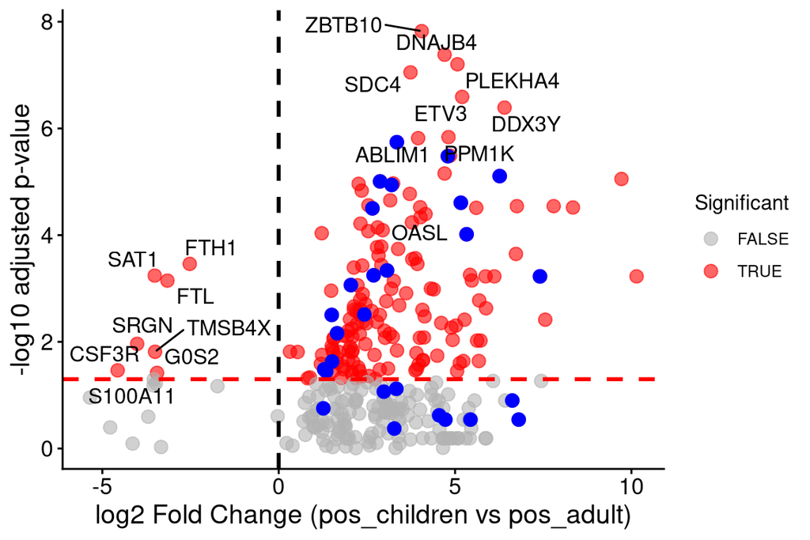

```r
# Set identity
Idents(seurat_subset) <- seurat_subset$covid_kid1

# Differential expression
de_res <- FindMarkers(
  seurat_subset,
  ident.1 = "pos_children",
  ident.2 = "pos_adult",
  logfc.threshold = 0,
  min.pct = 0.0
)



# Add gene names
de_res <- de_res %>%
  rownames_to_column("gene")

# Prepare volcano data
de_res <- de_res %>%
  mutate(
    log10_padj = -log10(p_val_adj),
    significant = p_val_adj < 0.05
  )

# Top 8 positive (children-enriched)
top_pos <- de_res %>%
  filter(avg_log2FC > 0) %>%
  arrange(p_val_adj) %>%
  slice_head(n = 8)

# Top 8 negative (adult-enriched)
top_neg <- de_res %>%
  filter(avg_log2FC < 0) %>%
  arrange(p_val_adj) %>%
  slice_head(n = 8)

writexl::write_xlsx(
       de_res,
       path = paste0(path2analysis,
                     "/degs_childres_vs_adults.xlsx")
)

# OAS genes
oas_genes <- de_res %>%
  filter(grepl("OASL", gene))

# Combine all labels
label_genes <- bind_rows(top_pos, top_neg, oas_genes) %>%
  distinct(gene, .keep_all = TRUE)

# Volcano plot
vulcano_child_vs_adult <- ggplot(subset(de_res, log10_padj > 0 ),
       aes(x = avg_log2FC, y = log10_padj)) +
  geom_point(aes(colour=significant),
             alpha = 0.6,
             size = 3) +
        geom_point(data = subset(de_res,
                                 gene %in% signatures$rigi_only  &
                                       log10_padj > 0 ),
                   aes(x = avg_log2FC, y = log10_padj),
                   colour = 'blue',
             size = 3) +
        geom_hline(yintercept = 1.3,
                   linetype = "dashed",
                   colour = "red",
                   linewidth = 1.0) +
        geom_vline(xintercept = 0,
                   linewidth = 1.0,
                   linetype = "dashed") +
  scale_color_manual(values = c("grey70", "red")) +
  geom_text_repel(
    data = label_genes,
    aes(label = gene),
    size = 4,
    max.overlaps = Inf
  ) +
  theme_classic() +
  labs(
    x = "log2 Fold Change (pos_children vs pos_adult)",
    y = "-log10 adjusted p-value",
    color = "Significant"
  ) +
  theme(
    axis.title = element_text(size = 14),
    axis.text  = element_text(size = 12)
  )

vulcano_child_vs_adult
```

```r
pdf(paste0(path2figures,
           '/volcano_plot_childern_vs_adult.pdf'),
     width=6, height=4)
vulcano_child_vs_adult
dev.off()
```

## GSEA of genes up-regulated in children (panel `dotplot_gsea.pdf`)

The top 200 significant (adjusted p < 0.05) up-regulated genes, ranked by log2 fold change, are mapped to Entrez IDs and tested with `gseGO` (GO Biological Process, no p-value cutoff). The 15 top terms are shown.

`gseGO` (fgsea) uses random permutations, so the result is stochastic; the original analysis did not fix a seed nor cache the result. Here a seed is set before `gseGO` so that this markdown is reproducible (small differences in p-values / term order relative to the original panel are expected). The GSEA result is saved to `analysis/supplementary_figure_03/gsea_up_children_vs_adults.rds` and `.xlsx`. (The original script also ran the same GSEA for the genes up-regulated in adults, which is not part of any panel and was dropped.)

```r
up_genes <- de_res %>%
  filter(significant, avg_log2FC > 0) %>%
  arrange(desc(avg_log2FC)) %>%
        head(200)

gene_map_up <- bitr(
  up_genes$gene,
  fromType = "SYMBOL",
  toType = "ENTREZID",
  OrgDb = org.Hs.eg.db
)
up_ranked <- up_genes %>%
  inner_join(gene_map_up, by = c("gene" = "SYMBOL")) %>%
  distinct(ENTREZID, .keep_all = TRUE)

geneList_up <- up_ranked$avg_log2FC
names(geneList_up) <- up_ranked$ENTREZID

geneList_up <- sort(geneList_up, decreasing = TRUE)

set.seed(1234)
gsea_up <- gseGO(
  geneList = geneList_up,
  OrgDb = org.Hs.eg.db,
  keyType = "ENTREZID",
  ont = "BP",
  pvalueCutoff = 1,
  verbose = FALSE
)
```

```r
saveRDS(gsea_up,
        file = paste0(path2analysis, "/gsea_up_children_vs_adults.rds"))
writexl::write_xlsx(
        as.data.frame(gsea_up@result),
        path = paste0(path2analysis, "/gsea_up_children_vs_adults.xlsx")
)

pdf(paste0(path2figures,
           "/dotplot_gsea.pdf"),
    width=6, height=4.0)
dotplot(gsea_up,
         showCategory = 15) +
  ggtitle("GO BP enrichment: Upregulated genes")
dev.off()
```

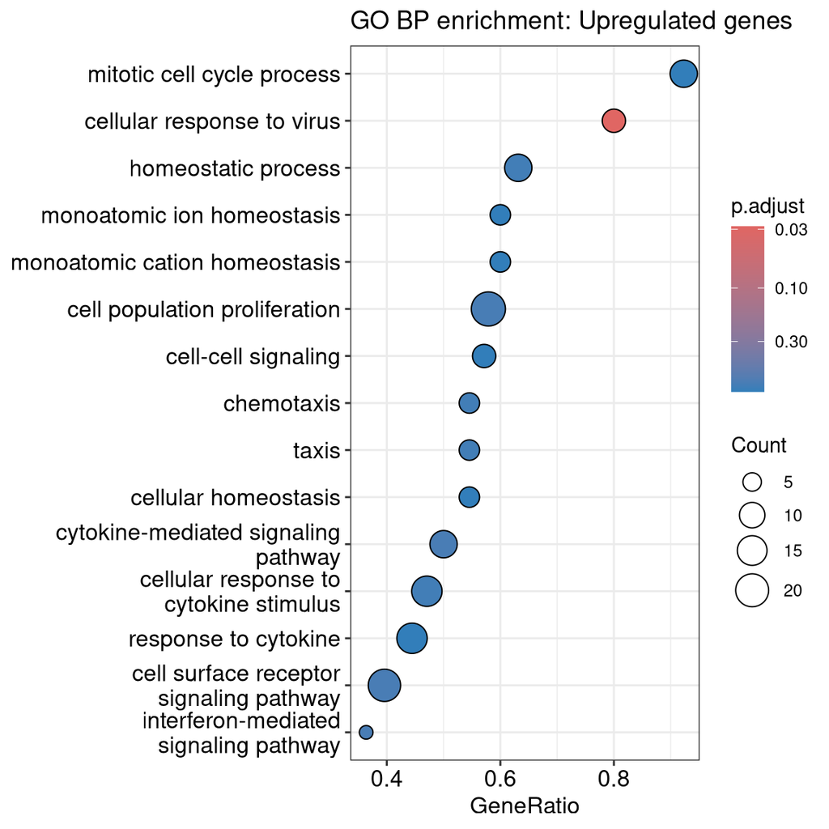

```r
dotplot(gsea_up,
         showCategory = 15) +
  ggtitle("GO BP enrichment: Upregulated genes")
```